# Ford GoBike System Data, March 2020

## by Seongsu Park

## Preliminary Wrangling

> This data is provided according to the Bay Wheels License Agreement, working with the transport corporate, Lyft, together. The data is the usage of GoBike in San Francisco, USA.

> The **COVID-19** situation makes peoople stay indoor, which can enormously affect the GoBike business. We need to understand how people tend to use this service especially on **March, 2020**.

### The main feature of data structure

- Trip Duration (seconds) : amount of the bike usage in second unit. We can use this variable to understand if the long-used bike is differed depending on the user types.
- User Type : (Subscriber / Customer) types of users who subscribe the gobike or not. We can track if there is a loyalty to this gobike.
- Rental Access Method : (Application / Clipper) the way of renting the bike. We can use this data if we need to give up advertising the clipper's way.
- Month : (March / February / January) the distribution in 2020. We can divide the data by month.

### New Trend of GoBike since COVID-19 started

- It might have been not too useful in the general situation, but in the COVID-19 situation, we need to understand the new trend of the customers since March, 2020. Therefore, rather than comparing the past policies and the trends, we will set up a blank white board and study as the first trial.
- **We will see the amount change of usage and the trend of using GoBike service since this COVID-19 situation, with the 4 datasets above.**
- As the Trip Duration (seconds) has a lot of outliers, we need to adjust the data only from 0 to 1775 seconds.

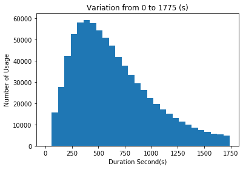

```python
bins = np.arange(0, Higher_Outlier, 60)
plt.hist(data=df, x='duration_sec', bins=bins)
plt.xlabel('Duration Second(s)')
plt.ylabel('Number of Usage')
plt.title('Variation from 0 to 1775 (s)');
```

### Significant Decrease from February to March in 2020

- The number of usage in February is more than 350 hundreds, but the usage in March is less than 150 hundreds.
- As we expected, the number of usage has been **decreased more than half in March.**

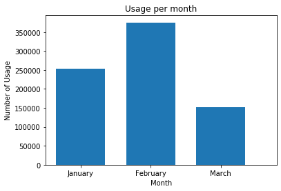

```python
bins = np.arange(0, 4, 1)
plt.hist(df['start_time'], bins=bins-0.35, width=0.7)
plt.xlabel('Month')
plt.ylabel('Number of Usage')
plt.title('Usage per month');
```

### Number of Usage between User Types per Month

- the subscriber, on the left, has been decreased from 250,000 in February to less than 100,000 in March. Also, the general customers has been decreased around 50,000 numbers.

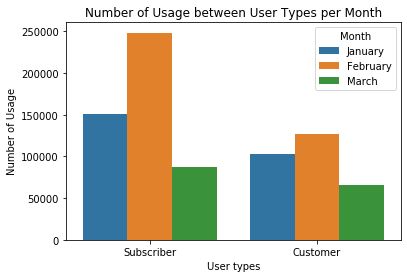

```python
sns.countplot(data = df, x='user_type', hue='start_time')
plt.title('Number of Usage between User Types per Month')
plt.xlabel('User types')
plt.ylabel('Number of Usage')
plt.legend(title="Month");
```

### Number of Usage between Access Methods per Month

- the application, on the left, has been decreased from 250,000 in February to less than 100,000 in March. Also, the clipper users has been decreased less than half.

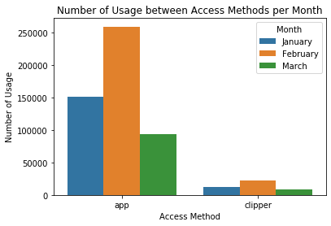

```python
sns.countplot(data = df, x='rental_access_method', hue='start_time')
plt.title('Number of Usage between Access Methods per Month')
plt.xlabel('Access Method')
plt.ylabel('Number of Usage')
plt.legend(title="Month");
```

### Duration Second(s) of each Month between Access Methods

- In every month, clipper users have the shorter bike usage duration than the applcation users' usage.
- Both application and the clipper users slightly have the decreasing usage from February to March.
- When we consider the previous study, that **people do not tend to use GoBike in March, users might try not to go outside.** Even though they need to use the bike, people tend to shorten the time to use the bike and go back home as soon as possible.
- Acorring to the clipper users in March, **when people use the GoBike instantly without the application, they try to use as less as they could.**

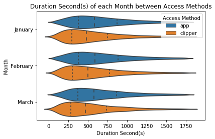

```python
sns.violinplot(data = df, x='duration_sec', y='start_time', inner = "quartile", hue='rental_access_method')
plt.title('Duration Second(s) of each Month between Access Methods')
plt.xlabel('Duration Second(s)')
plt.ylabel('Month')
plt.legend(title="Access Method");
```

### What To Do

> The tendency of decreasing in subscribers and the clippers especially means that **people do not see the GoBike in long-term right now.** Because no one knows when will become safe to ride a bike outside. Therefore, **GoBike has to stop losing subscribers and make an idea to make profit to the instant GoBike users.**